# DS202 lab 5

Andrew Fahmy

April 16, 2021

```r
    acc <- read.csv("https://raw.githubusercontent.com/xdaiISU/ds202materials/master/hwlabs/fars2017/accident.csv", stringsAsFactors = FALSE)
    person <- read.csv("https://raw.githubusercontent.com/xdaiISU/ds202materials/master/hwlabs/fars2017/person.csv", stringsAsFactors = FALSE)
```

### 1. Are there some days of the week where more accidents happen than the others (see FARS manual, use variable DAY_WEEK)?

```r
    library(tidyverse)
    names(acc)
```

```
##  [1] "STATE"      "ST_CASE"    "VE_TOTAL"   "VE_FORMS"   "PVH_INVL"
##  [6] "PEDS"       "PERNOTMVIT" "PERMVIT"    "PERSONS"    "COUNTY"
## [11] "CITY"       "DAY"        "MONTH"      "YEAR"       "DAY_WEEK"
## [16] "HOUR"       "MINUTE"     "NHS"        "RUR_URB"    "FUNC_SYS"
## [21] "RD_OWNER"   "ROUTE"      "TWAY_ID"    "TWAY_ID2"   "MILEPT"
## [26] "LATITUDE"   "LONGITUD"   "SP_JUR"     "HARM_EV"    "MAN_COLL"
## [31] "RELJCT1"    "RELJCT2"    "TYP_INT"    "WRK_ZONE"   "REL_ROAD"
## [36] "LGT_COND"   "WEATHER1"   "WEATHER2"   "WEATHER"    "SCH_BUS"
## [41] "RAIL"       "NOT_HOUR"   "NOT_MIN"    "ARR_HOUR"   "ARR_MIN"
## [46] "HOSP_HR"    "HOSP_MN"    "CF1"        "CF2"        "CF3"
## [51] "FATALS"     "DRUNK_DR"
```

```r
    names(person)
```

```
##  [1] "STATE"      "ST_CASE"    "VE_FORMS"   "VEH_NO"     "PER_NO"
##  [6] "STR_VEH"    "COUNTY"     "DAY"        "MONTH"      "HOUR"
## [11] "MINUTE"     "RUR_URB"    "FUNC_SYS"   "HARM_EV"    "MAN_COLL"
## [16] "SCH_BUS"    "MAKE"       "MAK_MOD"    "BODY_TYP"   "MOD_YEAR"
## [21] "TOW_VEH"    "SPEC_USE"   "EMER_USE"   "ROLLOVER"   "IMPACT1"
## [26] "FIRE_EXP"   "AGE"        "SEX"        "PER_TYP"    "INJ_SEV"
## [31] "SEAT_POS"   "REST_USE"   "REST_MIS"   "AIR_BAG"    "EJECTION"
## [36] "EJ_PATH"    "EXTRICAT"   "DRINKING"   "ALC_DET"    "ALC_STATUS"
## [41] "ATST_TYP"   "ALC_RES"    "DRUGS"      "DRUG_DET"   "DSTATUS"
## [46] "DRUGTST1"   "DRUGTST2"   "DRUGTST3"   "DRUGRES1"   "DRUGRES2"
## [51] "DRUGRES3"   "HOSPITAL"   "DOA"        "DEATH_DA"   "DEATH_MO"
## [56] "DEATH_YR"   "DEATH_HR"   "DEATH_MN"   "DEATH_TM"   "LAG_HRS"
## [61] "LAG_MINS"   "P_SF1"      "P_SF2"      "P_SF3"      "WORK_INJ"
## [66] "HISPANIC"   "RACE"       "LOCATION"
```

```r
    acc %>% group_by(DAY_WEEK) %>% summarise(n = n())
```

```
## # A tibble: 7 x 2
##   DAY_WEEK     n
##      <int> <int>
## 1        1  5360
## 2        2  4374
## 3        3  4347
## 4        4  4314
## 5        5  4621
## 6        6  5358
## 7        7  5873
```

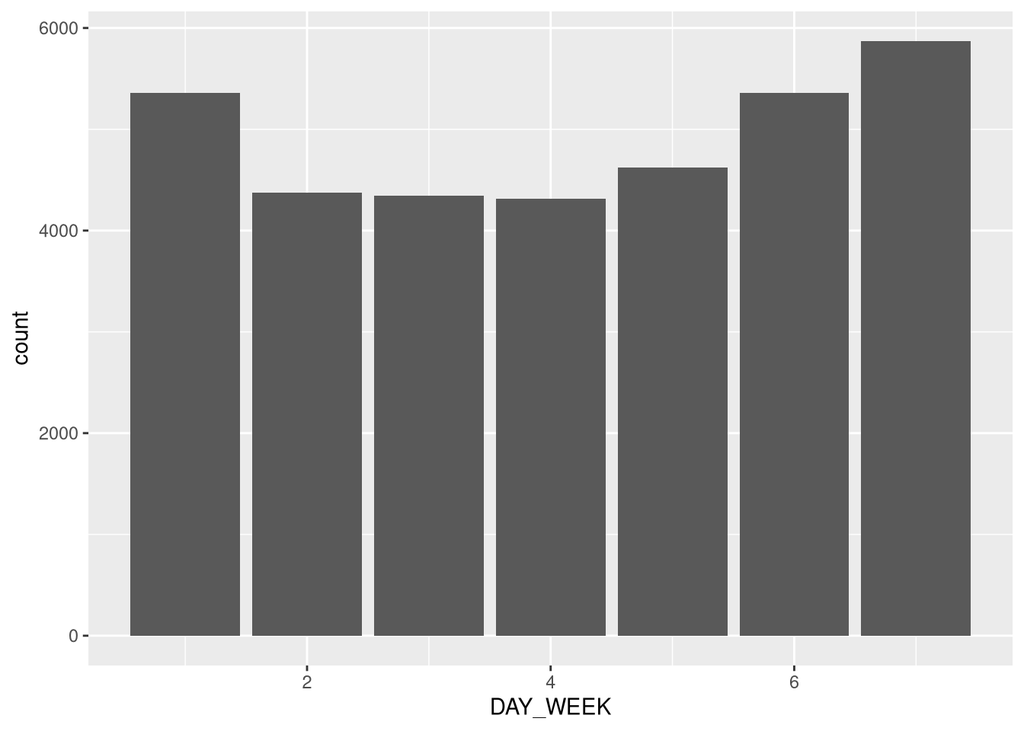

```r
    acc %>% ggplot(aes(x = DAY_WEEK)) + geom_bar()
```

It seems as if there are more accidents on the weekends then there are on the week days.

### 2. Create a data frame containing the persons who are fatally hurt in the accidents (look up variable INJ_SEV)

```r
    fatally_hurt <- person %>% filter(INJ_SEV == 4)
    #names(fatally_hurt)
    dim(fatally_hurt)
```

```
## [1] 37133    68
```

```r
    head(fatally_hurt)
```

[output not shown]

[output cut: 41 more lines]

### 3. Create a data frame containing the most dangerous vehicle make in each state. The number of persons fatally hit in the vehicle make is used to assess the (non-)safety of a make. Make sure to handle the missing values appropriately. (look up variable MAKE)

```r
    dangerous_vehicle <- fatally_hurt %>%
        filter(!is.na(MAKE)) %>%
        group_by(STATE) %>%
        count(MAKE) %>%
        top_n(1) %>%
        select(STATE, MAKE)
    dim(dangerous_vehicle)
```

```
## [1] 54  2
```

```r
    head(dangerous_vehicle)
```

```
## # A tibble: 6 x 2
## # Groups:   STATE [6]
##   STATE  MAKE
##   <int> <int>
## 1     1    12
## 2     2    12
## 3     4    20
## 4     5    20
## 5     6    49
## 6     8    12
```

### 4. Create a map, and label each state with the most dangerous vehicle. Discuss the definition of the most dangerous vehicle, and what you find from the map. (Hint: Read the description for the STATE and COUNTY columns in the FARS manual. The state & county codes are Geographic Locator Codes (GLCs) from the General Services Administration’s (GSA) publication. Use readxl::read_xlsx to read in the GLCs.)

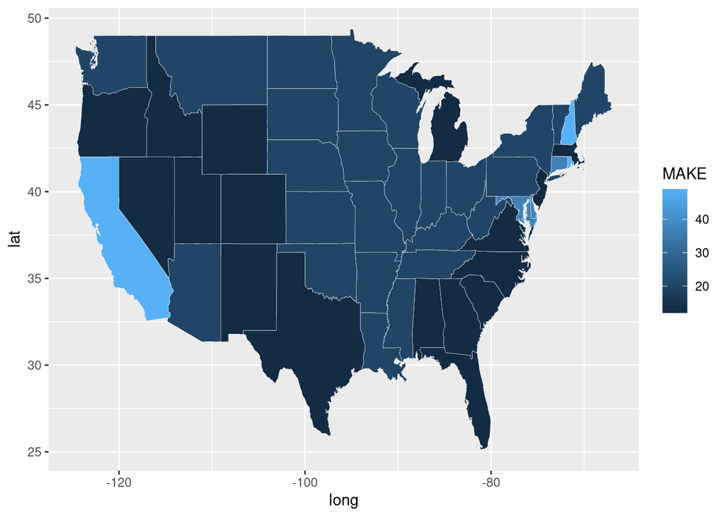

```r
    #install.packages("maps")
    library(maps)
    library(readxl)
    states <- map_data("state")
    glcs_us <- read_xlsx("GLCs_US.xlsx")
    states1 <- glcs_us %>%
        mutate(`State Code` = as.numeric(`State Code`)) %>%
        select("State Name", "State Code") %>%
        left_join(dangerous_vehicle, by = c("State Code" = "STATE"))

    states <- states %>%
        mutate(region = toupper(region)) %>%
        left_join(states1, by = c("region" = "State Name"))
    #str(data)

    states %>% ggplot(aes(x = long, y = lat, group = group, fill = MAKE)) +
        geom_polygon(color = "white", size = 0.1)
```

### 5. Join the accident and person table (work out which variable(s) to use)

```r
    dat <- acc %>% inner_join(person, by = "ST_CASE")
    dim(dat)
```

```
## [1] 84921   119
```

```r
    head(dat)
```

[output not shown]

[output cut: 83 more lines]

### 6. Tally the number of accidents by day of the week (DAY_WEEK), hour of the day (HOUR) and gender (SEX). Visualize the results and explain what you find.

```r
    # Day of week
    acc %>% group_by(DAY_WEEK) %>% summarise(n = n())
```

```
## # A tibble: 7 x 2
##   DAY_WEEK     n
##      <int> <int>
## 1        1  5360
## 2        2  4374
## 3        3  4347
## 4        4  4314
## 5        5  4621
## 6        6  5358
## 7        7  5873
```

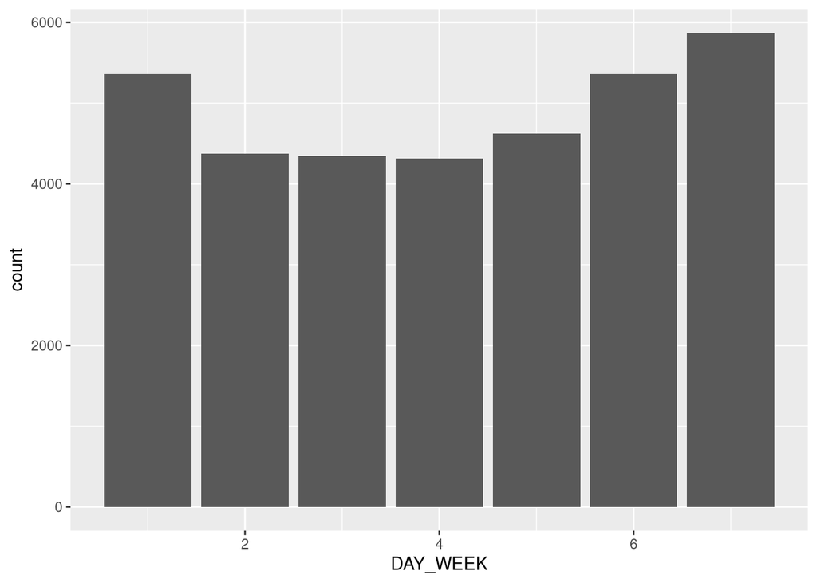

```r
    acc %>% ggplot(aes(x = DAY_WEEK)) + geom_bar()
```

```r
    # Hour of day
    acc %>% group_by(HOUR) %>% summarise(n = n())
```

```
## # A tibble: 25 x 2
##     HOUR     n
##    <int> <int>
##  1     0  1321
##  2     1  1177
##  3     2  1241
##  4     3   957
##  5     4   813
##  6     5  1065
##  7     6  1282
##  8     7  1162
##  9     8   945
## 10     9   929
## # … with 15 more rows
```

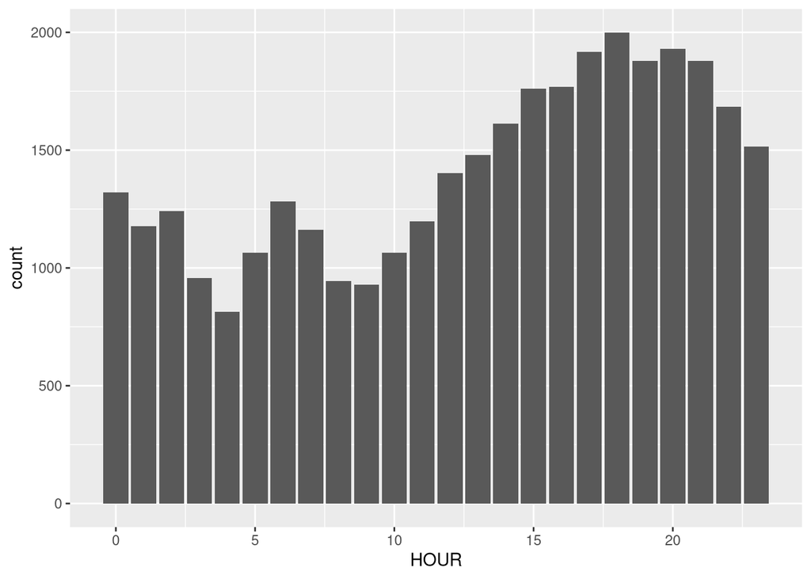

```r
    acc %>% filter(HOUR != 99) %>% ggplot(aes(x = HOUR)) + geom_bar()
```

```r
    # Sex
    dat %>% group_by(SEX) %>% summarise(n = n())
```

```
## # A tibble: 4 x 2
##     SEX     n
##   <int> <int>
## 1     1 55230
## 2     2 28149
## 3     8   473
## 4     9  1069
```

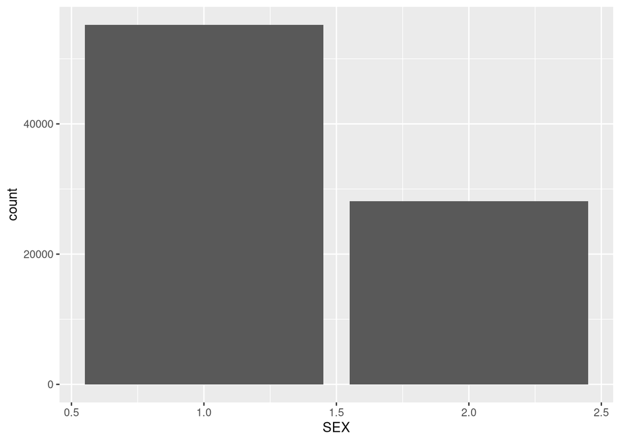

```r
    dat %>% filter(SEX <= 2) %>% ggplot(aes(x = SEX)) + geom_bar()
```

The number of accidents during the week is lowest near the being of the week starting on monday. It seems that people get in more accidents on the weekend and when it is approaching.

The most accidents seem to occur around 6-8pm. This may be due to people coming home from work and not having the same attention that they did in the morning.

Looking at the chart, we can see the males (left) are in almost double the number that females are. This may be due to men being more aggressive and having more driving jobs (like trucking for example)

### 7. Now plot a choropleth map of the number of deaths on a county level. Also explain what you find.

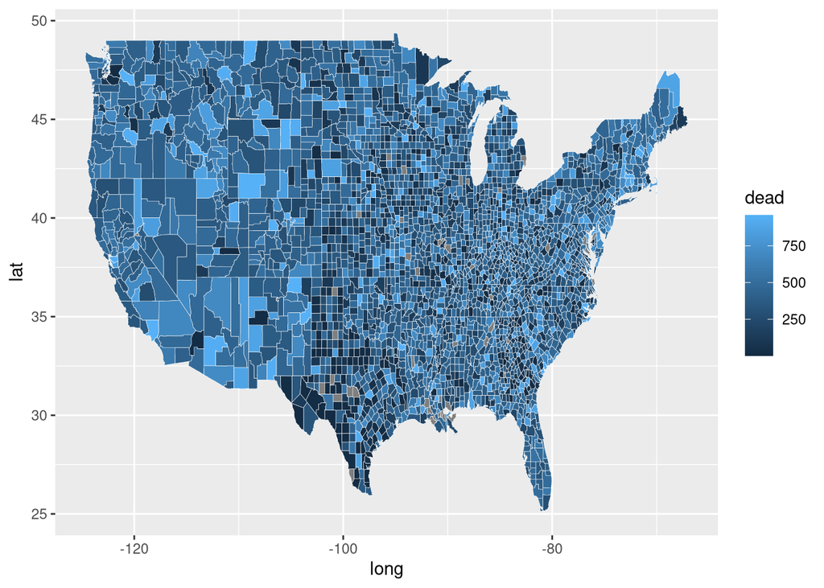

```r
    counties <- map_data("county")
    deaths <- fatally_hurt %>%
        group_by(COUNTY) %>%
        summarise(dead = n())
    #str(deaths)

    counties1 <- glcs_us %>%
        mutate("County Code" = as.numeric(`County Code`)) %>%
        select("County Name", "County Code") %>%
        left_join(deaths, by = c("County Code" = "COUNTY"))
    #str(counties1)

    counties <- counties %>%
        mutate(subregion = toupper(subregion)) %>%
        left_join(counties1, by = c("subregion" = "County Name"))
    #str(counties)

    counties %>% ggplot(aes(x = long, y = lat, group = group, fill = dead)) +
        geom_polygon(color = "white", size = 0.1)
```

### 8. Is summer or winter more dangerous? Does this depend on states? Explore and explain.

```r
    acc %>% group_by(MONTH) %>% summarise(n = n())
```

```
## # A tibble: 12 x 2
##    MONTH     n
##    <int> <int>
##  1     1  2616
##  2     2  2302
##  3     3  2686
##  4     4  2743
##  5     5  2896
##  6     6  3015
##  7     7  3226
##  8     8  2964
##  9     9  3068
## 10    10  3064
## 11    11  2852
## 12    12  2815
```

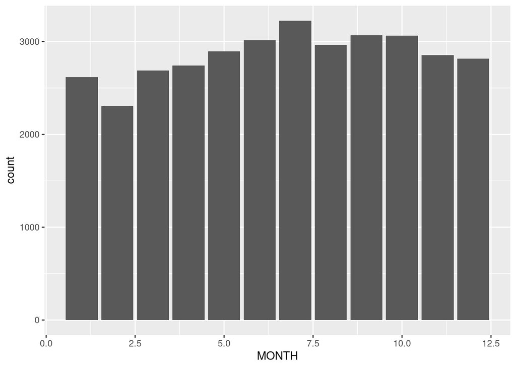

```r
    acc %>% ggplot(aes(x = MONTH)) + geom_bar()
```

You can see the number of accidents go up in the summer months near the middle of the graph. This may be due to more people being out driving and possibly not driving as safe.